# Bayesian GLMM Part3

Author

Murray Logan

Published

09/09/2025

# 1 Preparations

Load the necessary libraries

```r
library(tidyverse) # for data wrangling etc
library(rstanarm) # for fitting models in STAN
library(cmdstanr) # for cmdstan
library(brms) # for fitting models in STAN
library(standist) # for exploring distributions
library(HDInterval) # for HPD intervals
library(posterior) # for posterior draws
library(coda) # for diagnostics
library(bayesplot) # for diagnostics
library(ggmcmc) # for MCMC diagnostics
library(rstan) # for interfacing with STAN
library(emmeans) # for marginal means etc
library(broom) # for tidying outputs
library(DHARMa) # for residual diagnostics
library(tidybayes) # for more tidying outputs
library(ggeffects) # for partial plots
library(broom.mixed) # for tidying MCMC outputs
library(patchwork) # for multiple plots
library(ggridges) # for ridge plots
library(bayestestR) # for ROPE
library(see) # for some plots
library(easystats) # framework for stats, modelling and visualisation
library(modelsummary)
source("helperFunctions.R")
```

# 2 Scenario

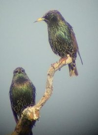

**Figure** 1: Starlings

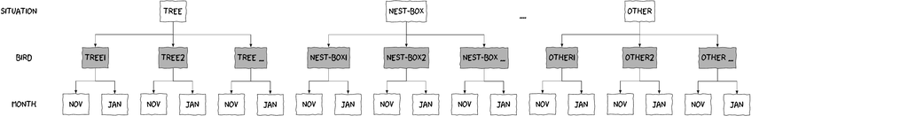

**Figure** 2: Sampling design for the starling data set

**Table** 1: Format of starling_full.csv data file

| SITUATION | MONTH | MASS | BIRD |
| --- | --- | --- | --- |
| tree | Nov | 78 | tree1 |
| .. | .. | .. | .. |
| nest-box | Nov | 78 | nest-box1 |
| .. | .. | .. | .. |
| inside | Nov | 79 | inside1 |
| .. | .. | .. | .. |
| other | Nov | 77 | other1 |
| .. | .. | .. | .. |
| tree | Jan | 85 | tree1 |
| .. | .. | .. | .. |

**Table** 2: Description of the variables in the starling_full data file

| **SITUATION** | Categorical listing of roosting situations (tree, nest-box, inside or other) |
| --- | --- |
| **MONTH** | Categorical listing of the month of sampling. |
| **MASS** | Mass (g) of starlings. |
| **BIRD** | Categorical listing of individual bird repeatedly sampled. |

# 3 Read in the data

```r
starling <- read_csv("../data/starling_full.csv", trim_ws = TRUE)
```

**glimpse**

```r
glimpse(starling)
```

```
Rows: 80
Columns: 5
$ MONTH      <chr> "Nov", "Nov", "Nov", "Nov", "Nov", "Nov", "Nov", "Nov", "No…
$ SITUATION  <chr> "tree", "tree", "tree", "tree", "tree", "tree", "tree", "tr…
$ subjectnum <dbl> 1, 2, 3, 4, 5, 6, 7, 8, 9, 10, 1, 2, 3, 4, 5, 6, 7, 8, 9, 1…
$ BIRD       <chr> "tree1", "tree2", "tree3", "tree4", "tree5", "tree6", "tree…
$ MASS       <dbl> 78, 88, 87, 88, 83, 82, 81, 80, 80, 89, 78, 78, 85, 81, 78,…
```

**head**

```r
## Explore the first 6 rows of the data
head(starling)
```

```
# A tibble: 6 × 5
  MONTH SITUATION subjectnum BIRD   MASS
  <chr> <chr>          <dbl> <chr> <dbl>
1 Nov   tree               1 tree1    78
2 Nov   tree               2 tree2    88
3 Nov   tree               3 tree3    87
4 Nov   tree               4 tree4    88
5 Nov   tree               5 tree5    83
6 Nov   tree               6 tree6    82
```

**str**

```r
str(starling)
```

```
spc_tbl_ [80 × 5] (S3: spec_tbl_df/tbl_df/tbl/data.frame)
 $ MONTH     : chr [1:80] "Nov" "Nov" "Nov" "Nov" ...
 $ SITUATION : chr [1:80] "tree" "tree" "tree" "tree" ...
 $ subjectnum: num [1:80] 1 2 3 4 5 6 7 8 9 10 ...
 $ BIRD      : chr [1:80] "tree1" "tree2" "tree3" "tree4" ...
 $ MASS      : num [1:80] 78 88 87 88 83 82 81 80 80 89 ...
 - attr(*, "spec")=
  .. cols(
  ..   MONTH = col_character(),
  ..   SITUATION = col_character(),
  ..   subjectnum = col_double(),
  ..   BIRD = col_character(),
  ..   MASS = col_double()
  .. )
 - attr(*, "problems")=<externalptr>
```

**Easystats (datawizard)**

```r
starling |> datawizard::data_codebook()
```

```
starling (80 rows and 5 variables, 5 shown)

ID | Name       | Type      | Missings |    Values |          N
---+------------+-----------+----------+-----------+-----------
1  | MONTH      | character | 0 (0.0%) |       Jan | 40 (50.0%)
   |            |           |          |       Nov | 40 (50.0%)
---+------------+-----------+----------+-----------+-----------
2  | SITUATION  | character | 0 (0.0%) |    inside | 20 (25.0%)
   |            |           |          |  nest-box | 20 (25.0%)
   |            |           |          |     other | 20 (25.0%)
   |            |           |          |      tree | 20 (25.0%)
---+------------+-----------+----------+-----------+-----------
3  | subjectnum | numeric   | 0 (0.0%) |   [1, 10] |         80
---+------------+-----------+----------+-----------+-----------
4  | BIRD       | character | 0 (0.0%) |   inside1 |  2 ( 2.5%)
   |            |           |          |  inside10 |  2 ( 2.5%)
   |            |           |          |   inside2 |  2 ( 2.5%)
   |            |           |          |   inside3 |  2 ( 2.5%)
   |            |           |          |   inside4 |  2 ( 2.5%)
   |            |           |          |   inside5 |  2 ( 2.5%)
   |            |           |          |   inside6 |  2 ( 2.5%)
   |            |           |          |   inside7 |  2 ( 2.5%)
   |            |           |          |   inside8 |  2 ( 2.5%)
   |            |           |          |   inside9 |  2 ( 2.5%)
   |            |           |          |     (...) |
---+------------+-----------+----------+-----------+-----------
5  | MASS       | numeric   | 0 (0.0%) | [68, 100] |         80
---------------------------------------------------------------
```

**Skim (modelsummary)**

Unique

Missing Pct.

Mean

SD

Min

Median

Max

Histogram

subjectnum

10

0

5.5

2.9

1.0

5.5

10.0

[figure not shown]

MASS

28

0

83.8

6.7

68.0

84.0

100.0

[figure not shown]

N

%

MONTH

Jan

40

50.0

Nov

40

50.0

SITUATION

inside

20

25.0

nest-box

20

25.0

other

20

25.0

tree

20

25.0

BIRD

inside1

2

2.5

inside10

2

2.5

inside2

2

2.5

inside3

2

2.5

inside4

2

2.5

inside5

2

2.5

inside6

2

2.5

inside7

2

2.5

inside8

2

2.5

inside9

2

2.5

nest-box1

2

2.5

nest-box10

2

2.5

nest-box2

2

2.5

nest-box3

2

2.5

nest-box4

2

2.5

nest-box5

2

2.5

nest-box6

2

2.5

nest-box7

2

2.5

nest-box8

2

2.5

nest-box9

2

2.5

other1

2

2.5

other10

2

2.5

other2

2

2.5

other3

2

2.5

other4

2

2.5

other5

2

2.5

other6

2

2.5

other7

2

2.5

other8

2

2.5

other9

2

2.5

tree1

2

2.5

tree10

2

2.5

tree2

2

2.5

tree3

2

2.5

tree4

2

2.5

tree5

2

2.5

tree6

2

2.5

tree7

2

2.5

tree8

2

2.5

tree9

2

2.5

```r
starling |> modelsummary::datasummary_skim()
```

SITUATION

MONTH

Unique

Missing Pct.

Mean

SD

Min

Median

Max

Histogram

subjectnum

tree

Nov

10

0

5.5

3.0

1.0

5.5

10.0

nest-box

Nov

10

0

5.5

3.0

1.0

5.5

10.0

inside

Nov

10

0

5.5

3.0

1.0

5.5

10.0

other

Nov

10

0

5.5

3.0

1.0

5.5

10.0

tree

Jan

10

0

5.5

3.0

1.0

5.5

10.0

nest-box

Jan

10

0

5.5

3.0

1.0

5.5

10.0

inside

Jan

10

0

5.5

3.0

1.0

5.5

10.0

other

Jan

10

0

5.5

3.0

1.0

5.5

10.0

MASS

tree

Nov

8

0

83.6

4.0

78.0

82.5

89.0

[figure not shown]

nest-box

Nov

6

0

79.4

3.2

74.0

79.5

85.0

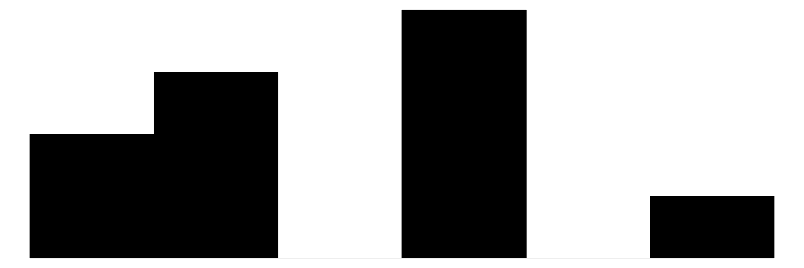

inside

Nov

8

0

78.6

3.3

73.0

78.5

84.0

[figure not shown]

other

Nov

8

0

75.4

4.5

68.0

75.0

84.0

[figure not shown]

tree

Jan

9

0

90.8

5.5

85.0

88.5

100.0

[figure not shown]

nest-box

Jan

8

0

90.2

4.4

84.0

89.5

96.0

[figure not shown]

inside

Jan

10

0

88.2

4.0

83.0

87.5

96.0

[figure not shown]

other

Jan

9

0

84.2

4.3

77.0

84.5

90.0

[figure not shown]

N

%

MONTH

Jan

40

50.0

Nov

40

50.0

SITUATION

inside

20

25.0

nest-box

20

25.0

other

20

25.0

tree

20

25.0

BIRD

inside1

2

2.5

inside10

2

2.5

inside2

2

2.5

inside3

2

2.5

inside4

2

2.5

inside5

2

2.5

inside6

2

2.5

inside7

2

2.5

inside8

2

2.5

inside9

2

2.5

nest-box1

2

2.5

nest-box10

2

2.5

nest-box2

2

2.5

nest-box3

2

2.5

nest-box4

2

2.5

nest-box5

2

2.5

nest-box6

2

2.5

nest-box7

2

2.5

nest-box8

2

2.5

nest-box9

2

2.5

other1

2

2.5

other10

2

2.5

other2

2

2.5

other3

2

2.5

other4

2

2.5

other5

2

2.5

other6

2

2.5

other7

2

2.5

other8

2

2.5

other9

2

2.5

tree1

2

2.5

tree10

2

2.5

tree2

2

2.5

tree3

2

2.5

tree4

2

2.5

tree5

2

2.5

tree6

2

2.5

tree7

2

2.5

tree8

2

2.5

tree9

2

2.5

```r
starling |> modelsummary::datasummary_skim(by = c("SITUATION", "MONTH"))
```

# 4 Exploratory data analysis

Random intercepts model formula:
$$\begin{align}
y_i &\sim{} \mathcal{N}(\mu_i, \sigma^2)\\
\mu_i &= \beta_0 + \boldsymbol{\beta} \bf{X_i} + \boldsymbol{\gamma} \bf{Z_i}\\
\boldsymbol{\gamma} &= \gamma_0\\
\beta_0 &\sim{} \mathcal{N}(80, 2.5)\\
\beta &\sim{} \mathcal{N}(0, 10)\\
\gamma_0 &\sim{} \mathcal{N}(0, \sigma_1^2)\\
\sigma &\sim{} \mathcal{t}(3, 0, 6)\\
\sigma_1 &\sim{} \mathcal{t}(3, 0, 6)\\
\end{align}$$

Random intercept/slope model formula:
$$\begin{align}
y_{i,j} &\sim{} \mathcal{N}(\mu_{i,j}, \sigma^2)\\
\mu_{i,j} &=\beta_0 + \bf{Z_j}\boldsymbol{\gamma_j} + \bf{X_i}\boldsymbol{\beta} \\
\beta_0 &\sim{} \mathcal{N}(80, 2)\\
\beta_1 &\sim{} \mathcal{N}(0, 10)\\
\boldsymbol{\gamma_j} &\sim{} \mathcal{N}(0, \boldsymbol{\Sigma})\\
\boldsymbol{\Sigma} &= \boldsymbol{D}({\sigma_l})\boldsymbol{\Omega}\boldsymbol{D}({\sigma_l^2})\\
\boldsymbol{\Omega} &\sim{} LKJ(\zeta)\\
\sigma_l^2 &\sim{} \mathcal{t}(3,0,3)\\
\sigma^2 &\sim{} \mathcal{t}(3, 0, 3)\
\end{align}$$

$$\begin{align}
\gamma &\sim{} N(0,\Sigma)\\
\Sigma &-> \Omega, \tau\\
\end{align}$$

where $\Sigma$ is a covariance matrix.

```r
starling <- starling |>
  mutate(
    BIRD = factor(BIRD),
    SITUATION = factor(SITUATION),
    MONTH = factor(MONTH, levels = c("Nov", "Jan"))
  )
```

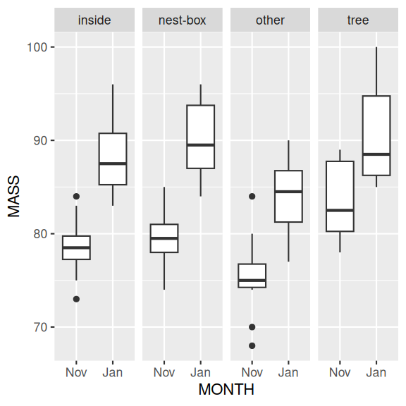

```r
ggplot(starling, aes(y = MASS, x = MONTH)) +
  geom_boxplot() +
  facet_grid(~SITUATION)
```

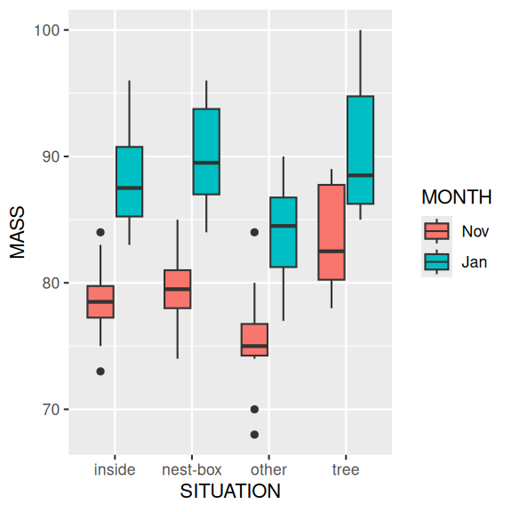

```r
ggplot(starling, aes(y = MASS, x = SITUATION, fill = MONTH)) +
  geom_boxplot()
```

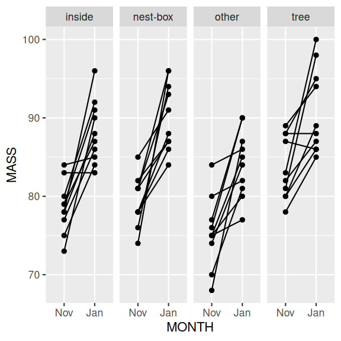

```r
## Better still
ggplot(starling, aes(y = MASS, x = MONTH, group = BIRD)) +
  geom_point() +
  geom_line() +
  facet_grid(~SITUATION)
```

# 5 Fit the model

**rstanarm**

**Using default priors**

In `rstanarm`, the default priors are designed to be weakly informative. They are chosen to provide moderate regularisation (to help prevent over-fitting) and help stabilise the computations.

```r
starling_rstanarm <- stan_glmer(MASS ~ MONTH * SITUATION + (1 | BIRD),
  data = starling,
  family = gaussian(),
  iter = 5000,
  warmup = 2000,
  chains = 3,
  thin = 5,
  refresh = 0
)
```

```r
starling_rstanarm %>% prior_summary()
```

```
Priors for model '.'
------
Intercept (after predictors centered)
  Specified prior:
    ~ normal(location = 84, scale = 2.5)
  Adjusted prior:
    ~ normal(location = 84, scale = 17)

Coefficients
  Specified prior:
    ~ normal(location = [0,0,0,...], scale = [2.5,2.5,2.5,...])
  Adjusted prior:
    ~ normal(location = [0,0,0,...], scale = [33.25,38.40,38.40,...])

Auxiliary (sigma)
  Specified prior:
    ~ exponential(rate = 1)
  Adjusted prior:
    ~ exponential(rate = 0.15)

Covariance
 ~ decov(reg. = 1, conc. = 1, shape = 1, scale = 1)
------
See help('prior_summary.stanreg') for more details
```

This tells us: - for the intercept (when the family is Gaussian), a normal prior with a mean of 84 and a standard deviation of 17 is used. The 2.5 is used for scaling all parameter standard deviations. The value of 84 is based on the mean of the response (`mean(starling$MASS)`) and the scaled standard deviation of 17 is based on multiplying the scaling factor by the standard deviation of the response.

```r
2.5 * sd(starling$MASS)
```

```
[1] 16.73225
```

- for the coefficients (in this case, the effects of MONTH, SEASON and their interactions), the default prior is a normal prior centred around 0 with a standard deviation of 2.5. This is then adjusted for the scale of the data by multiplying the 2.5 by the ratio of the standard deviation of the response by the standard deviation of the numerical dummy variables for the predictor (then rounded).

```r
2.5 * sd(starling$MASS) / apply(model.matrix(~ MONTH * SITUATION, starling)[, -1], 2, sd)
```

```
                  MONTHJan          SITUATIONnest-box
                  33.25470                   38.39922
            SITUATIONother              SITUATIONtree
                  38.39922                   38.39922
MONTHJan:SITUATIONnest-box    MONTHJan:SITUATIONother
                  50.27638                   50.27638
    MONTHJan:SITUATIONtree
                  50.27638
```

- the auxiliary prior represents whatever additional prior is required for the nominated model. In the case of a Gaussian model, this will be $\sigma$, for negative binomial, it will be the reciprocal of dispersion, for gamma, it will be shape, etc . By default in `rstanarm`, this is a exponential with a rate of 1 which is then adjusted by division with the standard deviation of the response.

```r
1 / sd(starling$MASS)
```

```
[1] 0.149412
```

**Assessing priors**

Lets now run with priors only so that we can explore the range of values they allow in the posteriors.

```r
starling_rstanarm1 <- update(starling_rstanarm, prior_PD = TRUE)
```

```
Note: uncertainty of error terms are not taken into account. Consider
  setting `interval` to "prediction". This will call `posterior_predict()`
  instead of `posterior_epred()`.
```

```
Data points may overlap. Use the `jitter` argument to add some amount of
  random variation to the location of data points and avoid overplotting.
```

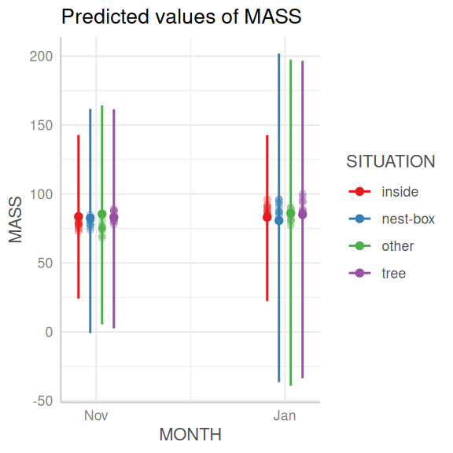

```r
starling_rstanarm1 %>%
  ggpredict(~ MONTH * SITUATION) %>%
  plot(show_data = TRUE)
```

**Conclusions:**

- we see that the range of predictions is fairly wide and the predicted means could range from a small value to a relatively large value.

**Defining priors**

The following link provides some guidance about defining priors. [https://github.com/stan-dev/stan/wiki/Prior-Choice-Recommendations]

When defining our own priors, we typically do not want them to be scaled.

If we wanted to define our own priors that were less vague, yet still not likely to bias the outcomes, we could try the following priors (mainly plucked out of thin air):

- $\beta_0$: normal centred at 84 with a standard deviation of 17
  - mean of 84: since `mean(starling$MASS)`
  - sd of 17: since `2.5*sd(starling$MASS)`
- $\beta_1$: normal centred at 0 with a standard deviation of 33
  - sd of 33: since `2.5*sd(starling$MASS) / apply(model.matrix(~MONTH*SITUATION, starling)[,-1], 2, sd)`
- $\beta_{2-4}$: normal centred at 0 with a standard deviation of 39
  - sd of 39: since `2.5*sd(starling$MASS) / apply(model.matrix(~MONTH*SITUATION, starling)[,-1], 2, sd)`
- $\beta_{5-7}$: normal centred at 0 with a standard deviation of 50
  - sd of 50: since `2.5*sd(starling$MASS) / apply(model.matrix(~MONTH*SITUATION, starling)[,-1], 2, sd)`
- $\sigma$: exponential with rate of 0.15
  - since `1 / sd(starling$MASS)`
- $\Sigma$: decov with:
  - regularisation: the exponent for a LKJ prior on the correlation matrix. A value of 1 (default) implies a joint uniform prior
  - concentration: the concentration parameter for a symmetric Dirichlet distribution. A value of 1 (default) implies a joint uniform distribution
  - shape and scale: the shape and scale parameters for a gamma prior on the scale and scale parameters of the decov prior. A value of 1 for both (default) simplifies the gamma prior to a unit-exponential distribution.

I will also overlay the raw data for comparison.

```r
starling_rstanarm2 <- stan_glmer(MASS ~ MONTH * SITUATION + (1 | BIRD),
  data = starling,
  family = gaussian(),
  prior_intercept = normal(84, 17, autoscale = FALSE),
  prior = normal(0, c(33, 39, 39, 39, 50, 50, 50), autoscale = FALSE),
  prior_aux = rstanarm::exponential(0.15, autoscale = FALSE),
  prior_covariance = decov(1, 1, 1, 1),
  prior_PD = TRUE,
  iter = 5000,
  warmup = 1000,
  chains = 3,
  thin = 5,
  refresh = 0
)
```

```
Note: uncertainty of error terms are not taken into account. Consider
  setting `interval` to "prediction". This will call `posterior_predict()`
  instead of `posterior_epred()`.
```

```
Data points may overlap. Use the `jitter` argument to add some amount of
  random variation to the location of data points and avoid overplotting.
```

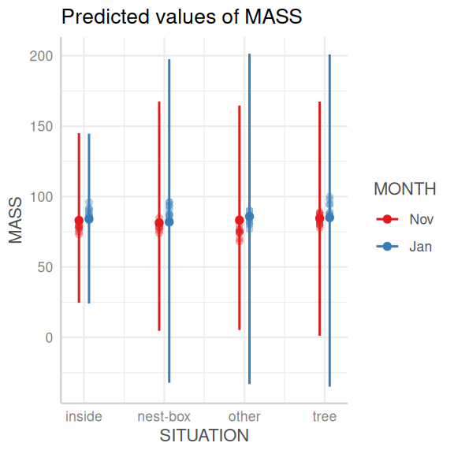

```r
starling_rstanarm2 %>%
  ggpredict(~ SITUATION * MONTH) %>%
  plot(show_data = TRUE)
```

Now lets refit, conditioning on the data.

```r
starling_rstanarm3 <- update(starling_rstanarm2, prior_PD = FALSE)
```

**Plotting prior and posterior**

```
Drawing from prior...
```

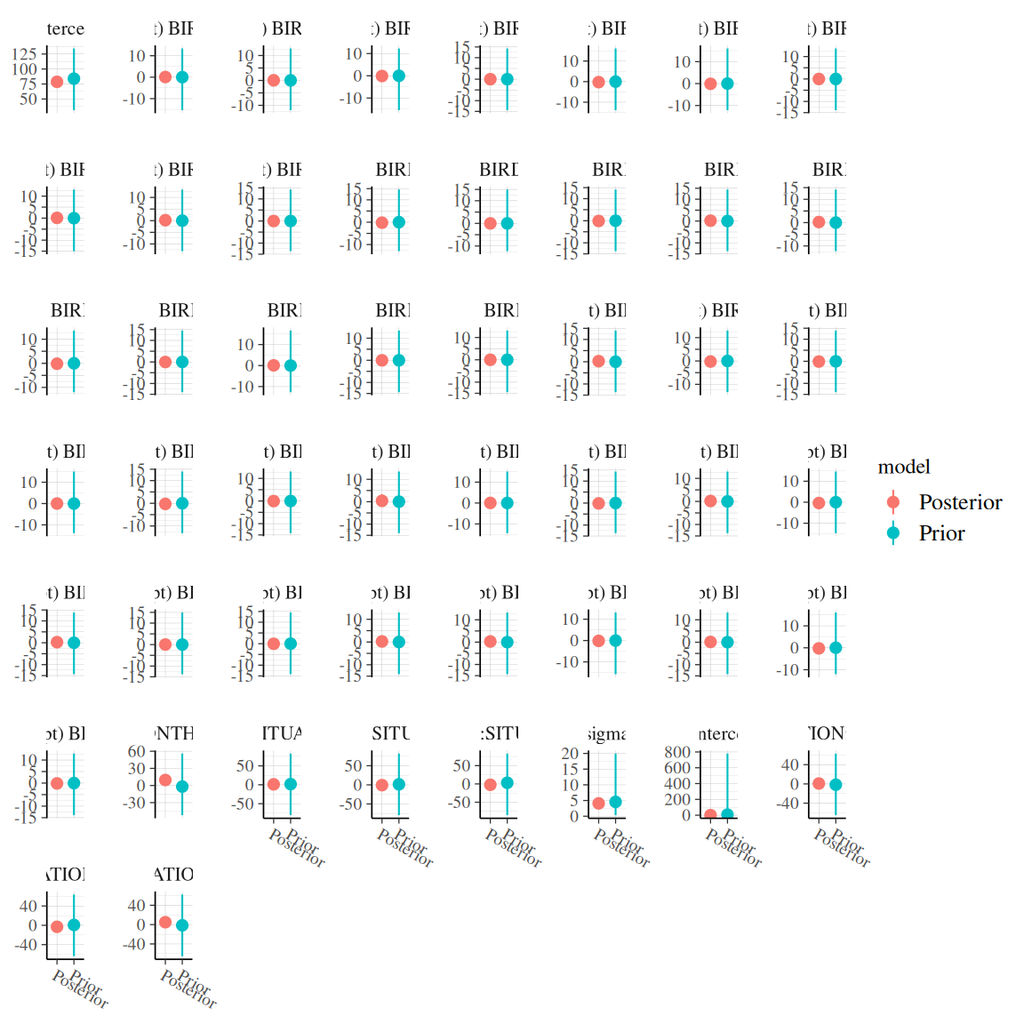

```r
posterior_vs_prior(starling_rstanarm3,
  color_by = "vs", group_by = TRUE,
  facet_args = list(scales = "free_y")
)
```

**Conclusions:**

- in each case, the prior is substantially wider than the posterior, suggesting that the posterior is not biased towards the prior.

```
Data points may overlap. Use the `jitter` argument to add some amount of
  random variation to the location of data points and avoid overplotting.
```

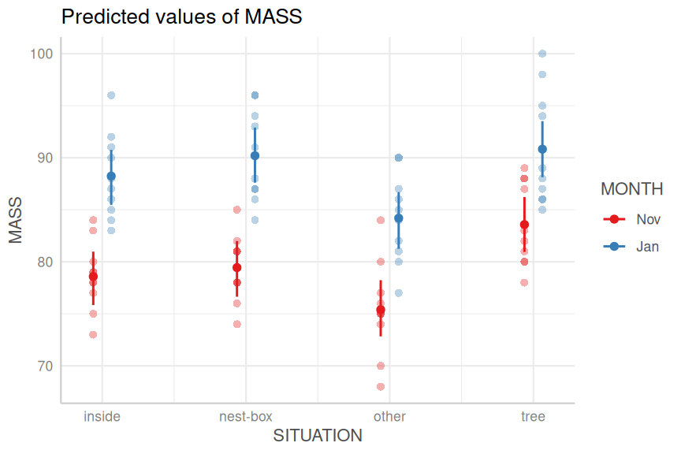

```r
ggemmeans(starling_rstanarm3, ~ SITUATION * MONTH) %>% plot(show_data = TRUE)
```

```
Note: uncertainty of error terms are not taken into account. Consider
  setting `interval` to "prediction". This will call `posterior_predict()`
  instead of `posterior_epred()`.
Data points may overlap. Use the `jitter` argument to add some amount of
  random variation to the location of data points and avoid overplotting.
```

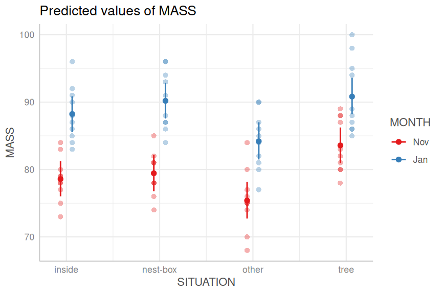

```r
ggpredict(starling_rstanarm3, ~ SITUATION * MONTH) %>% plot(show_data = TRUE)
```

**brms**

**Using default priors**

In `brms`, the default priors are designed to be weakly informative. They are chosen to provide moderate regularisation (to help prevent over fitting) and help stabilise the computations.

Unlike `rstanarm`, `brms` models must be compiled before they start sampling. For most models, the compilation of the stan code takes around 45 seconds.

```r
starling_form <- bf(MASS ~ MONTH*SITUATION+(MONTH + MONTH:SITUATION|BIRD),
  family = gaussian()
)
options(width=150)
starling_form |> get_prior(data = starling)
```

```
                 prior     class                       coef group resp dpar nlpar lb ub       source
                (flat)         b                                                             default
                (flat)         b                   MONTHJan                             (vectorized)
                (flat)         b MONTHJan:SITUATIONnestMbox                             (vectorized)
                (flat)         b    MONTHJan:SITUATIONother                             (vectorized)
                (flat)         b     MONTHJan:SITUATIONtree                             (vectorized)
                (flat)         b          SITUATIONnestMbox                             (vectorized)
                (flat)         b             SITUATIONother                             (vectorized)
                (flat)         b              SITUATIONtree                             (vectorized)
                lkj(1)       cor                                                             default
                lkj(1)       cor                             BIRD                       (vectorized)
 student_t(3, 84, 5.9) Intercept                                                             default
  student_t(3, 0, 5.9)        sd                                                   0         default
  student_t(3, 0, 5.9)        sd                             BIRD                  0    (vectorized)
  student_t(3, 0, 5.9)        sd                  Intercept  BIRD                  0    (vectorized)
  student_t(3, 0, 5.9)        sd                   MONTHJan  BIRD                  0    (vectorized)
  student_t(3, 0, 5.9)        sd MONTHJan:SITUATIONnestMbox  BIRD                  0    (vectorized)
  student_t(3, 0, 5.9)        sd    MONTHJan:SITUATIONother  BIRD                  0    (vectorized)
  student_t(3, 0, 5.9)        sd     MONTHJan:SITUATIONtree  BIRD                  0    (vectorized)
  student_t(3, 0, 5.9)        sd MONTHNov:SITUATIONnestMbox  BIRD                  0    (vectorized)
  student_t(3, 0, 5.9)        sd    MONTHNov:SITUATIONother  BIRD                  0    (vectorized)
  student_t(3, 0, 5.9)        sd     MONTHNov:SITUATIONtree  BIRD                  0    (vectorized)
  student_t(3, 0, 5.9)     sigma                                                   0         default
```

```r
options(width=80)
```

**Defining priors**

The following link provides some guidance about defining priors. [https://github.com/stan-dev/stan/wiki/Prior-Choice-Recommendations]

When defining our own priors, we typically do not want them to be scaled.

If we wanted to define our own priors that were less vague, yet still not likely to bias the outcomes, we could try the following priors (mainly plucked out of thin air):

- $\beta_0$: normal centred at 84 with a standard deviation of 5.9
  - mean of 84: since `median(starling$MASS)`
  - sd of 5.9: since `mad(starling$MASS)`
- $\beta_1$: normal centred at 0 with a standard deviation of 13
  - sd of 13: since `sd(starling$MASS) / apply(model.matrix(~MONTH*SITUATION, starling)[, -1], 2, sd)`
- $\beta_{2-4}$: normal centred at 0 with a standard deviation of 15
  - sd of 15: since `sd(starling$MASS) / apply(model.matrix(~MONTH*SITUATION, starling)[, -1], 2, sd)`
- $\beta_{5-7}$: normal centred at 0 with a standard deviation of 20
  - sd of 20: since `sd(starling$MASS) / apply(model.matrix(~MONTH*SITUATION, starling)[, -1], 2, sd)`
- $\sigma$: gamma with shape parameters 6.5 and 1
  - 6.5: since `sd(starling$MASS)`
- $\sigma_j$: half-cauchy with parameters 0 and 2.5.
  - 2.: since `sqrt(sd(starling$MASS))`
- $\Sigma$: decov with:
  - regularisation: the exponent for a LKJ prior on the correlation matrix. A value of 1 (default) implies a joint uniform prior
  - concentration: the concentration parameter for a symmetric Dirichlet distribution. A value of 1 (default) implies a joint uniform distribution
  - shape and scale: the shape and scale parameters for a gamma prior on the scale and scale parameters of the decov prior. A value of 1 for both (default) simplifies the gamma prior to a unit-exponential distribution.

Note, for hierarchical models, the model will tend to want to have a large $sigma$ in order to fit the data better. It is a good idea to **regularise** this tendency by applying a prior that has most mass around zero. Suitable candidates include:

- half-t: as the degrees of freedom approach infinity, this will approach a half-normal
- half-cauchy: this is essentially a half-t with 1 degree of freedom
- exponential

I will also overlay the raw data for comparison.

```r
starling_form <- bf(MASS ~ MONTH * SITUATION + (1 | BIRD),
  family = gaussian()
)
get_prior(starling_form, data = starling)
```

```
                 prior     class                       coef group resp dpar
                (flat)         b
                (flat)         b                   MONTHJan
                (flat)         b MONTHJan:SITUATIONnestMbox
                (flat)         b    MONTHJan:SITUATIONother
                (flat)         b     MONTHJan:SITUATIONtree
                (flat)         b          SITUATIONnestMbox
                (flat)         b             SITUATIONother
                (flat)         b              SITUATIONtree
 student_t(3, 84, 5.9) Intercept
  student_t(3, 0, 5.9)        sd
  student_t(3, 0, 5.9)        sd                             BIRD
  student_t(3, 0, 5.9)        sd                  Intercept  BIRD
  student_t(3, 0, 5.9)     sigma
 nlpar lb ub       source
                  default
             (vectorized)
             (vectorized)
             (vectorized)
             (vectorized)
             (vectorized)
             (vectorized)
             (vectorized)
                  default
        0         default
        0    (vectorized)
        0    (vectorized)
        0         default
```

```r
starling |>
  group_by(SITUATION, MONTH) |>
  summarise(
    mean(MASS),
    median(MASS),
    sd(MASS),
    mad(MASS)
  )
```

```
# A tibble: 8 × 6
# Groups:   SITUATION [4]
  SITUATION MONTH `mean(MASS)` `median(MASS)` `sd(MASS)` `mad(MASS)`
  <fct>     <fct>        <dbl>          <dbl>      <dbl>       <dbl>
1 inside    Nov           78.6           78.5       3.31        2.22
2 inside    Jan           88.2           87.5       4.05        4.45
3 nest-box  Nov           79.4           79.5       3.20        2.22
4 nest-box  Jan           90.2           89.5       4.37        5.19
5 other     Nov           75.4           75         4.53        2.22
6 other     Jan           84.2           84.5       4.26        4.45
7 tree      Nov           83.6           82.5       4.03        5.19
8 tree      Jan           90.8           88.5       5.47        4.45
```

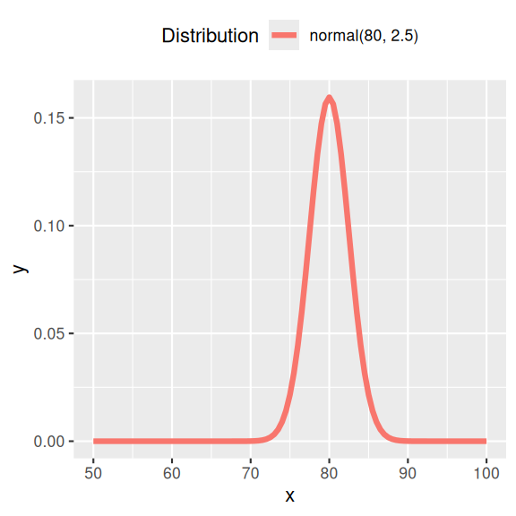

```r
standist::visualize("normal(80, 2.5)", xlim = c(50, 100))
```

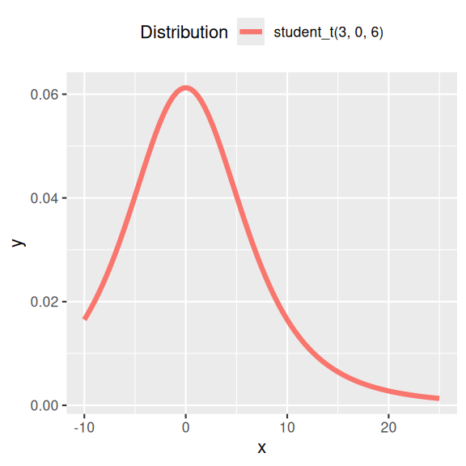

```r
standist::visualize("student_t(3, 0, 6)",
  xlim = c(-10, 25)
)
```

```r
priors <- prior(normal(80, 2.5), class = "Intercept") +
  ## prior(normal(0, 13), class = 'b', coef = "MONTHJan") +
  ## prior(normal(0, 15), class = 'b', coef = "SITUATIONnestMbox") +
  ## prior(normal(0, 15), class = 'b', coef = "SITUATIONother") +
  ## prior(normal(0, 15), class = 'b', coef = "SITUATIONtree") +
  prior(normal(0, 10), class = "b") +
  ## prior(gamma(6.5,1), class = 'sigma') +
  prior(student_t(3, 0, 6), class = "sigma") +
  prior(student_t(3, 0, 6), class = "sd")
starling_brm2 <- brm(starling_form,
  data = starling,
  prior = priors,
  sample_prior = "only",
  iter = 5000,
  warmup = 1000,
  chains = 3, cores = 3,
  thin = 5,
  refresh = 0,
  backend = "rstan"
)
```

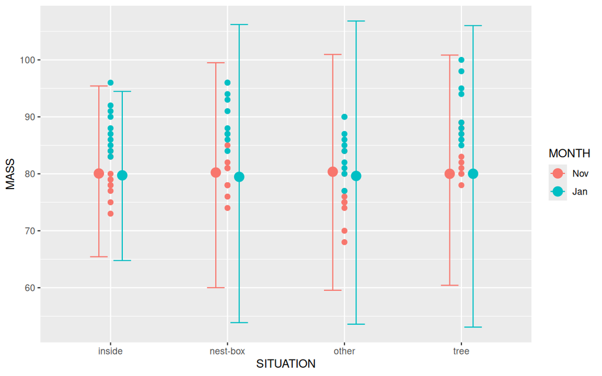

```r
starling_brm2 |>
  conditional_effects("SITUATION:MONTH") |>
  plot(points = TRUE)
```

```
Note: uncertainty of error terms are not taken into account. Consider
  setting `interval` to "prediction". This will call `posterior_predict()`
  instead of `posterior_epred()`.
```

```
Data points may overlap. Use the `jitter` argument to add some amount of
  random variation to the location of data points and avoid overplotting.
```

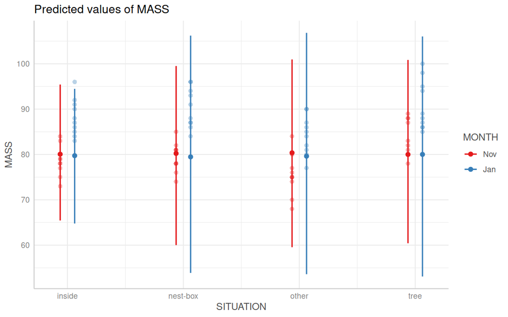

```r
starling_brm2 |>
  ggpredict(~ SITUATION * MONTH) |>
  plot(show_data = TRUE)
```

The above seem sufficiently wide whilst at the same time not providing any encouragement for the sampler to wander off into very unsupported areas.

```r
starling_brm3 <- update(starling_brm2,
  sample_prior = "yes",
  control = list(adapt_delta = 0.99),
  refresh = 0
)
```

```
The desired updates require recompiling the model
```

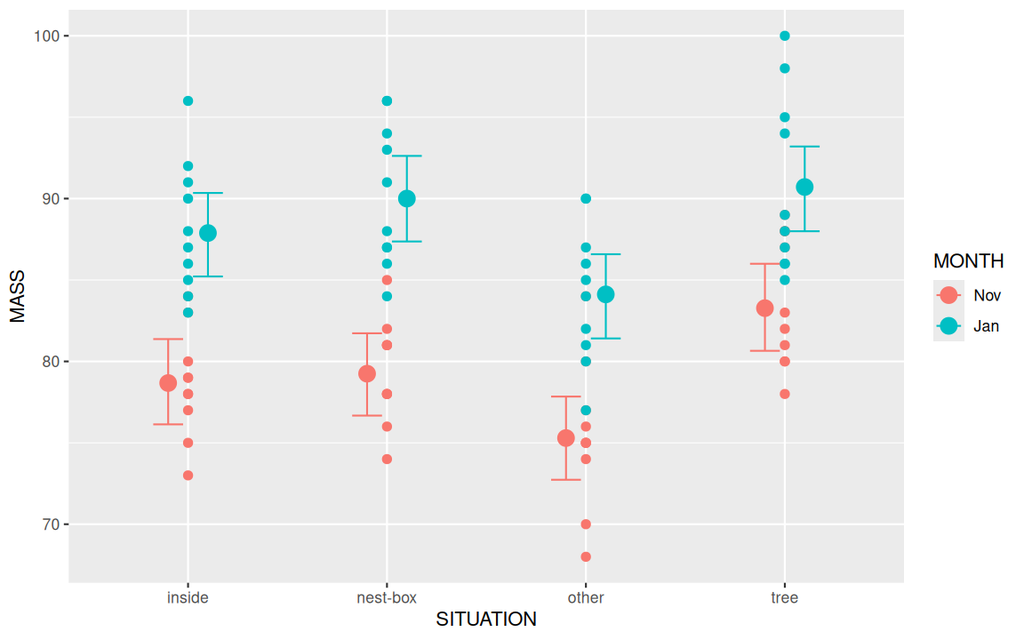

```r
starling_brm3 |>
  conditional_effects("SITUATION:MONTH") |>
  plot(points = TRUE)
```

```
Note: uncertainty of error terms are not taken into account. Consider
  setting `interval` to "prediction". This will call `posterior_predict()`
  instead of `posterior_epred()`.
```

```
Data points may overlap. Use the `jitter` argument to add some amount of
  random variation to the location of data points and avoid overplotting.
```

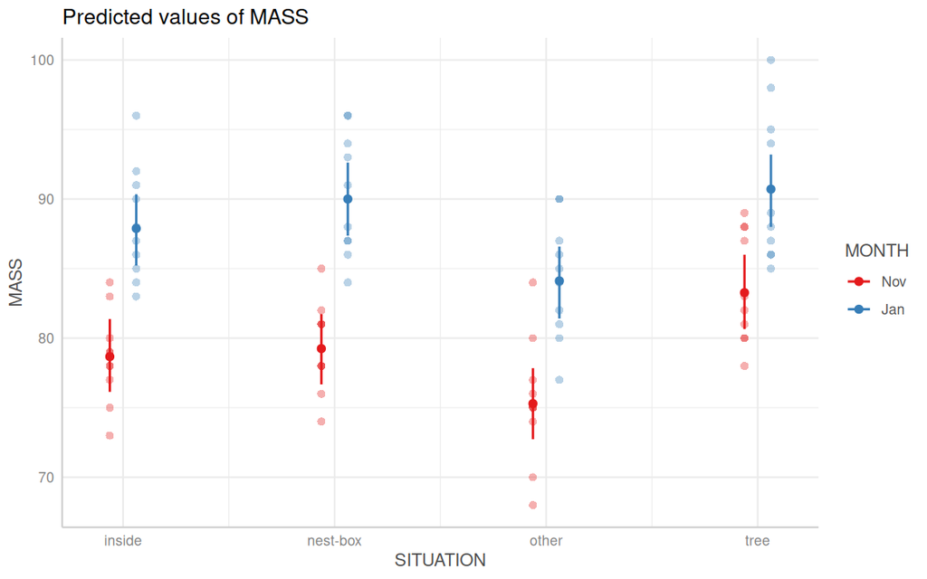

```r
starling_brm3 |>
  ggpredict(~ SITUATION * MONTH) |>
  plot(show_data = TRUE)
```

**Plotting prior and posterior**

```r
starling_brm3 |> get_variables()
```

```
 [1] "b_Intercept"                  "b_MONTHJan"
 [3] "b_SITUATIONnestMbox"          "b_SITUATIONother"
 [5] "b_SITUATIONtree"              "b_MONTHJan:SITUATIONnestMbox"
 [7] "b_MONTHJan:SITUATIONother"    "b_MONTHJan:SITUATIONtree"
 [9] "sd_BIRD__Intercept"           "sigma"
[11] "Intercept"                    "r_BIRD[inside1,Intercept]"
[13] "r_BIRD[inside10,Intercept]"   "r_BIRD[inside2,Intercept]"
[15] "r_BIRD[inside3,Intercept]"    "r_BIRD[inside4,Intercept]"
[17] "r_BIRD[inside5,Intercept]"    "r_BIRD[inside6,Intercept]"
[19] "r_BIRD[inside7,Intercept]"    "r_BIRD[inside8,Intercept]"
[21] "r_BIRD[inside9,Intercept]"    "r_BIRD[nest-box1,Intercept]"
[23] "r_BIRD[nest-box10,Intercept]" "r_BIRD[nest-box2,Intercept]"
[25] "r_BIRD[nest-box3,Intercept]"  "r_BIRD[nest-box4,Intercept]"
[27] "r_BIRD[nest-box5,Intercept]"  "r_BIRD[nest-box6,Intercept]"
[29] "r_BIRD[nest-box7,Intercept]"  "r_BIRD[nest-box8,Intercept]"
```

[output cut: 17 more lines]

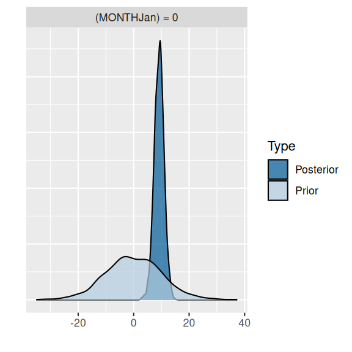

```r
starling_brm3 |>
  hypothesis("MONTHJan=0") |>
  plot()
```

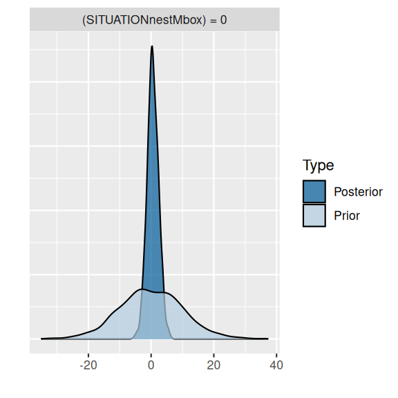

```r
starling_brm3 |>
  hypothesis("SITUATIONnestMbox=0") |>
  plot()
```

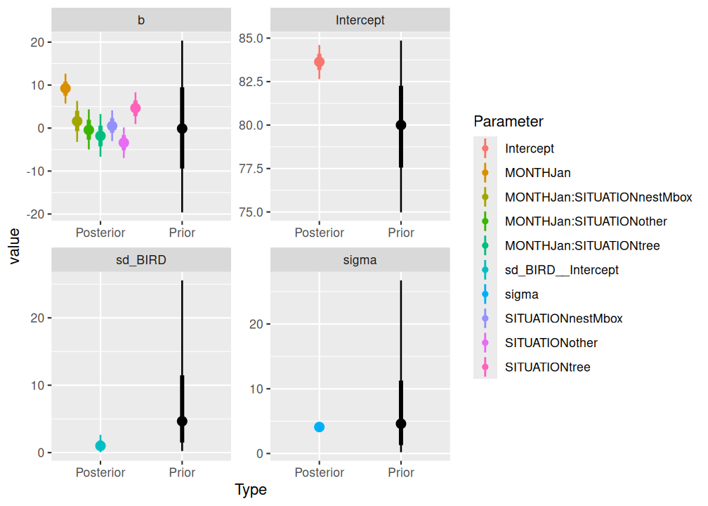

```r
starling_brm3 |> SUYR_prior_and_posterior()
```

**Random intercept/slope model**

While we are here, we might like to explore a random intercept/slope model

```r
# I am going to narrow the priors so as to stabalise the model
priors <- prior(normal(80, 2), class = "Intercept") +
  # prior(normal(0, 13), class = 'b', coef = "MONTHJan") +
  # prior(normal(0, 15), class = 'b', coef = "SITUATIONnestMbox") +
  # prior(normal(0, 15), class = 'b', coef = "SITUATIONother") +
  # prior(normal(0, 15), class = 'b', coef = "SITUATIONtree") +
  prior(normal(0, 10), class = "b") +
  ## prior(gamma(6.5,1), class = 'sigma') +
  prior(student_t(3, 0, 3), class = "sigma") +
  prior(student_t(3, 0, 3), class = "sd") +
  prior(lkj_corr_cholesky(1), class = "cor")

starling_form <- bf(MASS ~ MONTH * SITUATION + (MONTH | BIRD),
  family = gaussian()
)
starling_brm3a <- brm(starling_form,
  data = starling,
  prior = priors,
  sample_prior = "only",
  iter = 5000,
  warmup = 2500,
  chains = 3, cores = 3,
  thin = 5,
  refresh = 0,
  control = list(adapt_delta = 0.99),
  backend = "rstan"
)
starling_brm4 <- brm(starling_form,
  data = starling,
  prior = priors,
  sample_prior = "yes",
  iter = 10000, # note, these changes are in response to issues
  warmup = 5000,
  chains = 3, cores = 3,
  thin = 10, # some autocorrelation noted
  refresh = 0,
  control = list(adapt_delta = 0.99, max_treedepth = 20)
)
```